# Project Proposal

World Athletics Championships 2025, Tokyo — Data Visualisation Analysis and Redesign

Authors

Goh Jason Fadil (2502643)

Venus Low (2503741)

Choong Wan Qin (2402311)

Chi Wei Seng (2401493)

Koh Soon Chuan (2400951)

Published

6 March 2026

## 1 Chosen Visualisation and Story

The selected data visualisation presents a comprehensive overview of the events and medal results from the 2025 World Athletics Championships, held in Tokyo, Japan. The competition encompasses a wide range of track and field disciplines spanning multiple categories, including events for Male, Female and Mixed participants.

The primary narrative conveyed by the visualisation is the breadth of competitive events held during the championship, as well as the medal winners for each respective event. The original visualisation is interactive in nature: upon hovering over individual data points, the viewer is presented with detailed information pertaining to that entry, including the athlete’s country of representation, full name, performance score, and the date on which the event was contested.

However, despite its visual appeal, the dashboard has a critical usability weakness - it is entirely dependent on user interaction to reveal any meaningful information. At a quick glance, a viewer is unable to draw any conclusions from the visualization, as no data values are displayed directly on the bubbles themselves.

For example, if a user wanted to determine which country won the most total medals, they would need to hover over every single bubble within the top 3 ranking positions and manually tally the counts in their head. There are no summary statistics, no persistent labels, and no pre-aggregated views to support this basic analytical question. This design forces the user to become the engine of the analysis, sequentially exploring data point by data point which leads to significant time inefficiency and cognitive overload, particularly when dealing with 49 events each containing up to 8 ranked athletes

Originally published on Tableau Public, the visualisation is designed to allow users to explore the championship results at a granular level, with a focus on individual athlete performances across the various events.

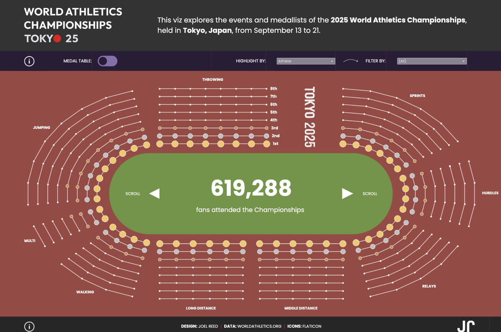

Reference: [World Athletics Championships 2025, Tokyo — Tableau Public](https://public.tableau.com/app/profile/joelreed/viz/WorldAthleticsChampionships2025Tokyo/WorldAthleticsChampionships2025Tokyo)

## 2 Strengths and Weaknesses of the Original Visualisation

### 2.1 Strengths

- Aesthetic coherence: The visualisation is visually well-crafted and thematically consistent with the subject matter, adopting a track-inspired design that aligns appropriately with the nature of a track and field competition.
- Interactive data exploration: The chart supports hover interactions that surface detailed athlete-level information, including name, country of representation, performance score, and ranking position (top 8 per event).
- Event categorisation: All championship events are present within the visualisation and are logically grouped into broader event categories such as sprints, throwing events, and jumping events, facilitating high-level browsing.
- Breadth of coverage: The visualization encompasses all 49 events across men’s and women’s disciplines, representing 53 nations in a single cohesive dashboard.

### 2.2 Weaknesses

- Absence of at-a-glance insights: At first glance, the visualisation does not convey any meaningful conclusion to the viewer. All substantive information is locked behind user interaction with individual data points, which encode the following dimensions: Event Type (Male/Female/Mixed), Event Name (e.g., 100m, 200m) and Country.
- High cognitive load for aggregated queries: Determining which country won the highest total number of medals, for example, requires the user to hover over every data point within the top three ranking positions and manually tally the results. This imposes substantial time inefficiency and cognitive overload on the viewer.
- Full interactivity dependency: The visualisation is entirely dependent on user interaction to surface data, offering no passive or summary-level view. This design choice significantly limits its effectiveness as a standalone analytical communication tool.

While the original visualisation has great aesthetic presentation and interactive exploration, it lacks the analytical hierarchy, making it hard to compare the data easily. As a result, viewers are required to manually extract the insights which limits the effectiveness of the visualisation.

## 3 Proposed Improvements

The following improvements are proposed to enhance the analytical clarity and communicative value of the visualisation.

### 3.1 Country-Level Medal Overview

- Objective: Provide a broader, summary-level view of total medal counts across competing nations.
- Problem Addressed: Prevents the viewer from becoming overwhelmed by granular data without first establishing the overall competitive landscape.
- Value Delivered: By anchoring the viewer’s attention to a high-level medal count comparison, the visualisation provides essential context before presenting event-specific detail. The audience can readily identify the leading nations before exploring individual performance data, transforming the chart from a technical reference into a coherent competitive narrative.

### 3.2 Country Performance by Event Type

- Objective: Highlight which countries excelled in specific athletic disciplines.
- Problem Addressed: Addresses the analytical questions of *where* and *how* national athletic success was achieved.
- Value Delivered: Understanding which countries performed best in particular event groups (e.g., javelin, marathon) reveals the source of a nation’s athletic strength. This makes the visualisation actionable and enables analysts to identify regional concentrations of talent across specific athletic disciplines.

### 3.3 Event Performance Breakdown by Gender

- Objective: Illustrate the distribution of competitive performance across Male, Female and Mixed event categories.
- Problem Addressed: Adds analytical depth by addressing the question of *why* certain patterns in national or event-level performance emerge.
- Value Delivered: Moving beyond simple rankings, this dimension reveals the health and balance of national athletic programmes. Notable patterns may include smaller nations achieving disproportionate success in female-category events, or dominant sporting nations extending their strength into the newly integrated mixed relay disciplines.

The table below summarises the key differences between the original Tableau dashboard and our proposed visualisation.

| Analytical Aspect | Original Visualisation | Proposed Redesign | Key Improvement |
| --- | --- | --- | --- |
| Primary Perspective | Event-centric (individual athlete results) | Country-centric (aggregated medal counts) | Shifts focus from micro-level exploration to macro-level comparison |
| Starting Point | No clear starting point as all events are shown simultaneously | Country-level medal overview presented first | Establishes analytical hierarchy |
| Medal Comparison Across Countries | Requires manual hovering and mental tallying | Direct comparison via stacked bar chart | Enables immediate at-a-glance insight |
| Event Discipline Analysis | Events displayed individually without structured aggregation | Events grouped into broader categories (running, jumping, throwing, combined) | Reveals national specialisation patterns |
| **Gender-Based Comparison** | Gender differences inferred through manual exploration | Faceted layout (Male/Female/Mixed × Country) | Enables structured, systematic gender comparison |
| Information Accessibility | Fully dependent on interactive hover tooltips | All medal counts visible without interaction | Reduces cognitive load and improves static readability |
| **Perceptual Encoding** | Bubble area encoding (low precision for comparison) | Bar length encoding (high perceptual accuracy) | Improves quantitative comparability |
| Cognitive Load | High — sequential inspection required | Lower — structured grid supports parallel comparison | Enhances analytical efficiency |
| Analytical Depth | Descriptive (who won which event) | Comparative (where dominance occurs and how performance is distributed) | Adds explanatory dimension (where & why) |

## 4 Data Source Details

All data were sourced directly from the official [World Athletics Championships website](https://worldathletics.org/competitions/world-athletics-championships/world-athletics-championships-tokyo-2025-7190593). Results were collected via manual web scraping and subsequently compiled into a structured spreadsheet for analysis.

The dataset encompasses all medal results for each event held during the 2025 championship, including athlete name, country of representation, performance score, ranking position, event name, event group, gender category, and competition date.

## 5 Detailed Workflow: From Raw Data to Visualisation-Ready Data

The following steps outline the end-to-end data engineering pipeline employed to transform raw source data into a format suitable for visualisation.

1. Define project objectives and identify the key dimensions represented in the original visualisation (Ranking, Gender Category, Event Name, Event Group, Country).
2. Collect raw data from the official [World Athletics Championships website](https://worldathletics.org/competitions/world-athletics-championships/world-athletics-championships-tokyo-2025-7190593) via structured web scraping.
3. Define the scope of the dataset, confirming which events, ranking positions, and athlete attributes are required for the proposed visualisation.
4. Perform initial data cleaning to remove duplicate entries, handle missing values (`NA`), and ensure consistent formatting across all fields.
5. Athletic events are categorised into higher-level sport groups (e.g., Running, Jumping, Throwing, Combined) via a case_when() transformation applied within the R visualisation pipeline, as the raw dataset contains individual event names only.
6. Validate and cross-reference the cleaned dataset against official championship results to ensure accuracy and completeness.
7. Export the cleaned dataset in CSV format for use within the Quarto Markdown (.qmd) visualisation pipeline. Medal tallies by country, gender category, and event group are subsequently computed within the R visualisation code using group_by(), summarise(), and expand.grid() transformations at render time.

### 5.1 Dimensions of the Original Visualisation

| Dimension | Description |
| --- | --- |
| Ranking | Finishing position (1st, 2nd, 3rd, etc.) |
| Gender Category | Male, Female, or Mixed |
| Event Name | e.g., 100m, 200m, Long Jump |
| Event Group | e.g., Jumping, Sprints, Throwing |
| Country | Country of representation |

### 5.2 Proposed Visualisation Dimensions

[output not shown]

## 6 Proposed Visualisation

The code chunk below produces the proposed visualisation using ggplot2. It reads from the cleaned dataset, aggregates medal counts by country, medal type, gender category, and event group, and renders a faceted stacked bar chart.

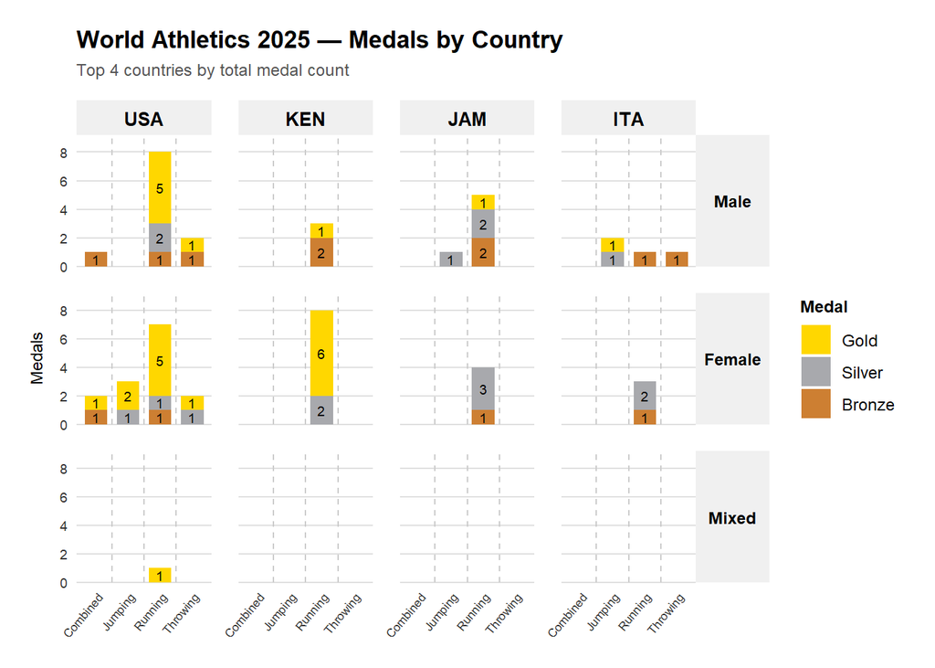

```r
library(ggplot2)
library(dplyr)
library(tidyr)

# ── 1. Load data ──────────────────────────────────────────────────────────────
data <- read.csv("wac_2025_medalists.csv")

# ── 2. Prepare: event groups, gender labels, medal types ─────────────────────
data <- data |>
  mutate(
    EventGroup = case_when(
      EVENT %in% c("100M", "200M", "400M", "800M", "1500M",
                   "5000M", "10000M", "MARATHON",
                   "100M HURDLES", "110M HURDLES", "400M HURDLES",
                   "3000M STEEPLECHASE",
                   "4X100 METRES RELAY", "4X400 METRES RELAY",
                   "20 KILOMETRES RACE WALK", "35 KILOMETRES RACE WALK") ~ "Running",
      EVENT %in% c("HIGH JUMP", "LONG JUMP",
                   "TRIPLE JUMP", "POLE VAULT")                          ~ "Jumping",
      EVENT %in% c("SHOT PUT", "DISCUS THROW",
                   "HAMMER THROW", "JAVELIN THROW")                      ~ "Throwing",
      EVENT %in% c("DECATHLON", "HEPTATHLON")                           ~ "Combined",
      TRUE ~ "Other"
    ),
    GenderLabel = case_when(
      MIXED == 1    ~ "Mixed",
      GENDER == "M" ~ "Male",
      GENDER == "F" ~ "Female",
      TRUE          ~ as.character(GENDER)
    ),
    MedalType = case_when(
      POSITION == 1 ~ "Gold",
      POSITION == 2 ~ "Silver",
      POSITION == 3 ~ "Bronze",
      TRUE          ~ NA_character_
    )
  )

# ── 3. Keep medals only ───────────────────────────────────────────────────────
medals <- data |> filter(!is.na(MedalType))

# ── 4. Top 3 countries by total medal count ───────────────────────────────────
top4 <- medals |>
  group_by(COUNTRY) |>
  summarise(Total = n(), .groups = "drop") |>
  slice_max(Total, n = 4) |>
  pull(COUNTRY)

# ── 5. Build complete grid: every event × every gender × every country ───────
# This ensures all events appear even when a country won nothing in that event
all_events <- medals |>
  filter(COUNTRY %in% top4) |>
  pull(EVENT) |>
  unique() |>
  sort()

all_genders <- c("Male", "Female", "Mixed")

full_grid <- expand.grid(
  COUNTRY     = top4,
  GenderLabel = all_genders,
  EVENT       = all_events,
  MedalType   = c("Gold", "Silver", "Bronze"),
  stringsAsFactors = FALSE
)

# Aggregate actual medal counts
actual <- medals |>
  filter(COUNTRY %in% top4) |>
  group_by(COUNTRY, GenderLabel, EVENT, MedalType) |>
  summarise(Medals = n(), .groups = "drop")

# Join so missing combinations become 0
plot_data <- full_grid |>
  left_join(actual, by = c("COUNTRY", "GenderLabel", "EVENT", "MedalType")) |>
  replace_na(list(Medals = 0)) |>
  # Re-attach EventGroup for labelling
  left_join(
    data |> select(EVENT, EventGroup) |> distinct(),
    by = "EVENT"
  ) |>
  mutate(
    MedalType   = factor(MedalType,   levels = c("Gold", "Silver", "Bronze")),
    GenderLabel = factor(GenderLabel, levels = c("Male", "Female", "Mixed")),
    COUNTRY     = factor(COUNTRY,     levels = top4),
    EVENT       = factor(EVENT,       levels = all_events)
  )

# ── 6. Actual gold / silver / bronze colours ──────────────────────────────────
medal_colours <- c(
  "Gold"   = "#FFD700",
  "Silver" = "#A8A9AD",
  "Bronze" = "#CD7F32"
) # ── 7. Plot ───────────────────────────────────────────────────────────────────
ggplot(plot_data,
  aes(x = EventGroup, y = Medals, fill = MedalType)
  ) +
  geom_col(width = 0.7, position = "stack"
  ) +
  geom_text(
    data = plot_data |>
      group_by(COUNTRY, GenderLabel, EventGroup, MedalType) |>
      summarise(Medals = sum(Medals), .groups = "drop"),
    aes(label = ifelse(Medals > 0, Medals, "")),
    position = position_stack(vjust = 0.5),
    size = 2.5,
    colour = "black"
  ) +
  # Vertical dashed lines to separate event groups
  geom_vline(
    xintercept = c(1.5, 2.5, 3.5),
    colour = "#cccccc",
    linewidth = 0.4,
    linetype = "dashed"
  ) +
  # Equal column widths: fixed scales so every panel has the same x-axis
  facet_grid(
    rows = vars(GenderLabel),
    cols = vars(COUNTRY)
  ) +
  scale_fill_manual(values = medal_colours, name = "Medal") +
  scale_y_continuous(
    expand = expansion(mult = c(0, 0.15)),
    breaks = scales::pretty_breaks(n = 4)
  ) +
  labs(
    title = "World Athletics 2025 — Medals by Country",
    subtitle = "Top 4 countries by total medal count",
    x = NULL,
    y = "Medals"
  ) +
  theme_minimal(base_size = 11) +
  theme(
    # White background
    plot.background    = element_rect(fill = "white", colour = NA),
    panel.background   = element_rect(fill = "white", colour = NA),
    strip.background   = element_rect(fill = "#f0f0f0", colour = NA),

    # Grid lines — light grey horizontal only
    panel.grid.major.y = element_line(colour = "#e0e0e0"),
    panel.grid.major.x = element_blank(),
    panel.grid.minor   = element_blank(),

    # Panel spacing — adds visible gaps between facets
    panel.spacing.x    = unit(1, "lines"),
    panel.spacing.y    = unit(1, "lines"),

    # Black text
    text               = element_text(colour = "black"),
    axis.text          = element_text(colour = "#333333", size = 7),
    axis.text.x        = element_text(angle = 50, hjust = 1, size = 6.5),
    axis.title.y       = element_text(size = 9, margin = margin(r = 8)),
    strip.text.x       = element_text(face = "bold", colour = "black", size = 10),
    strip.text.y       = element_text(face = "bold", colour = "black", size = 9,
                                      angle = 0),

    # Title
    plot.title         = element_text(face = "bold", size = 13, colour = "black"),
    plot.subtitle      = element_text(size = 9, colour = "#555555",
                                      margin = margin(b = 12)),
    plot.margin        = margin(t = 16, r = 16, b = 16, l = 16),

    # Legend
    legend.position    = "right",
    legend.title       = element_text(face = "bold", size = 9),
    legend.text        = element_text(size = 9),
    legend.key         = element_rect(fill = "white", colour = NA)


  )
```

## 8 Work Distribution

[output not shown]